# Linear Regression

2023-09-17

## Linear Regression

We’ll load the tidyverse package, but we’ll explicitly name other packages to reinforce learning on their functions and package source.

```r
# Helper packages
library(tidyverse)
```

We’ll use data from the previous chapter.

```r
ames_train <- read_rds("results/ch01_ames_train.rds")
ames_test <- read_rds("results/ch01_ames_test.rds")
```

### Simple linear regression

#### Estimation

The traditional specification of this model in R is done with the `lm` function.

```r
model1 <- lm(
    Sale_Price ~ Gr_Liv_Area,
    data = ames_train)
```

This function does several things, that in the `tidymodels` would be expected to be done in different steps: - It specifies the model - It fits the model

The function `summary` is a generic that knows how to interpret the model and display it for a user.

```r
summary(model1)
```

```
##
## Call:
## lm(formula = Sale_Price ~ Gr_Liv_Area, data = ames_train)
##
## Residuals:
##     Min      1Q  Median      3Q     Max
## -474682  -30794   -1678   23353  328183
##
## Coefficients:
##              Estimate Std. Error t value Pr(>|t|)
## (Intercept) 15938.173   3851.853   4.138 3.65e-05 ***
## Gr_Liv_Area   109.667      2.421  45.303  < 2e-16 ***
## ---
## Signif. codes:  0 '***' 0.001 '**' 0.01 '*' 0.05 '.' 0.1 ' ' 1
##
## Residual standard error: 56790 on 2047 degrees of freedom
## Multiple R-squared:  0.5007, Adjusted R-squared:  0.5004
## F-statistic:  2052 on 1 and 2047 DF,  p-value: < 2.2e-16
```

And if we are only interested in the coefficients the function `coef` can provide these:

```r
coef(model1)
```

```
## (Intercept) Gr_Liv_Area
##  15938.1733    109.6675
```

If we wanted to replicate this modelling with the `tidymodels` package instead, it could be done with the following steps:

```r
model_wf_01 <- workflows::workflow() %>%
    workflows::add_formula(
        Sale_Price ~ Gr_Liv_Area) %>%
    workflows::add_model(
        parsnip::linear_reg() %>%
            parsnip::set_engine("lm") %>%
            parsnip::set_mode("regression")) %>%
    parsnip::fit(
        data = ames_train)
```

The `broom` package provides functions to inspect the model parameters in a way that can be easily manipulated later:

```r
broom::tidy(model_wf_01)
```

```
## # A tibble: 2 × 5
##   term        estimate std.error statistic   p.value
##   <chr>          <dbl>     <dbl>     <dbl>     <dbl>
## 1 (Intercept)   15938.   3852.        4.14 3.65e-  5
## 2 Gr_Liv_Area     110.      2.42     45.3  5.17e-311
```

#### Inference

The function `confint` provides an interval for the parameters for a given level of confidence:

```r
confint(model1, level = 0.95)
```

```
##                2.5 %     97.5 %
## (Intercept) 8384.213 23492.1336
## Gr_Liv_Area  104.920   114.4149
```

### Multiple linear regression

A multiple linear regression can be also run with the same model `lm`.

```r
model2 <- lm(
    Sale_Price ~ Gr_Liv_Area + Year_Built,
    data = ames_train)
```

With `tidymodels` this would be done with:

```r
model_wf_02 <- model_wf_01 %>%
    workflows::update_formula(
        Sale_Price ~ Gr_Liv_Area + Year_Built) %>%
    parsnip::fit(
        data = ames_train)
```

Interactions can be included in the model as well:

```r
lm(
    Sale_Price ~ Gr_Liv_Area + Year_Built + Gr_Liv_Area:Year_Built,
    data = ames_train)
```

```
##
## Call:
## lm(formula = Sale_Price ~ Gr_Liv_Area + Year_Built + Gr_Liv_Area:Year_Built,
##     data = ames_train)
##
## Coefficients:
##            (Intercept)             Gr_Liv_Area              Year_Built  Gr_Liv_Area:Year_Built
##             -8.105e+05              -7.285e+02               4.309e+02               4.168e-01
```

Finally the model could have been run over the whole set of available features.

```r
model3 <- lm(
    Sale_Price ~ .,
    data = ames_train)

broom::tidy(model3)
```

```
## # A tibble: 300 × 5
##    term                                                estimate std.error statistic p.value
##    <chr>                                                  <dbl>     <dbl>     <dbl>   <dbl>
##  1 (Intercept)                                       -27256503. 11016450.   -2.47    0.0134
##  2 MS_SubClassOne_Story_1945_and_Older                    3901.     3575.    1.09    0.275
##  3 MS_SubClassOne_Story_with_Finished_Attic_All_Ages     -5389.    12164.   -0.443   0.658
##  4 MS_SubClassOne_and_Half_Story_Unfinished_All_Ages      -441.    13942.   -0.0316  0.975
##  5 MS_SubClassOne_and_Half_Story_Finished_All_Ages        1037.     7250.    0.143   0.886
##  6 MS_SubClassTwo_Story_1946_and_Newer                   -6669.     5510.   -1.21    0.226
##  7 MS_SubClassTwo_Story_1945_and_Older                    1574.     6074.    0.259   0.795
##  8 MS_SubClassTwo_and_Half_Story_All_Ages                 3408.    10149.    0.336   0.737
##  9 MS_SubClassSplit_or_Multilevel                        -6670.    11673.   -0.571   0.568
## 10 MS_SubClassSplit_Foyer                                 1492.     7512.    0.199   0.843
## # ℹ 290 more rows
```

```r
model_wf_03 <- model_wf_02 %>%
    workflows::update_formula(
        Sale_Price ~ .) %>%
    parsnip::fit(
        data = ames_train)
```

Notice how there’s been some feature engineering behind the scenes, as this is required by the `lm` model. The problem is that we don’t control in this case explicitly what’s been done.

### Assessing model’s performance

To define model’s performance it’s important to define what we mean by “better”. Usual measures are RMSE (root mean squared error) o MAE (mean absolute error). These are measures of how well the model can predict the target given some features for an observation that the model hasn’t seen before.

In practice there are other relevant measures such as the time required to train the model, make a prediction or the computational effort required.

As discussed elsewhere it’s better to train the model with an analysis set and measure performance with an assessment set, where both the analysis and assessment sets are subsets of the training set. Then the testing set is only used to measure effectiveness of the final selected model.

As seen in the book so far, this can be done either with the `caret` package or with the more modern `tidymodels` set of packages.

```r
# Train model with 10-fold cross validation using caret

set.seed(123)

cv_model_01 <- caret::train(
    form = Sale_Price ~ Gr_Liv_Area,
    data = ames_train,
    method = "lm",
    trControl = caret::trainControl(
        method = "cv",
        number = 10))
```

Let’s do the same using the `tidymodels` packages instead.

```r
# V-Fold cross-validation

vfold_01 <- rsample::vfold_cv(
    data = ames_train,
    v = 10)

# Fit resamples and measure performance

cv_model_02 <- tune::fit_resamples(
    object = model_wf_01,
    resamples = vfold_01,
    metrics = yardstick::metric_set(
        yardstick::rmse,
        yardstick::mae),
    control = tune::control_resamples(
        save_pred = TRUE)
    )

tune::collect_metrics(cv_model_02)
```

```
## # A tibble: 2 × 6
##   .metric .estimator   mean     n std_err .config
##   <chr>   <chr>       <dbl> <int>   <dbl> <chr>
## 1 mae     standard   38890.    10    693. Preprocessor1_Model1
## 2 rmse    standard   56911.    10   1387. Preprocessor1_Model1
```

```r
tune::collect_predictions(cv_model_02)
```

```
## # A tibble: 2,049 × 5
##    id       .pred  .row Sale_Price .config
##    <chr>    <dbl> <int>      <int> <chr>
##  1 Fold01  97450.     4     125000 Preprocessor1_Model1
##  2 Fold01 138437.    45      64000 Preprocessor1_Model1
##  3 Fold01 109924.    68      97000 Preprocessor1_Model1
##  4 Fold01 115270.    84     129000 Preprocessor1_Model1
##  5 Fold01 129638.   107     128000 Preprocessor1_Model1
##  6 Fold01 150020.   110     115000 Preprocessor1_Model1
##  7 Fold01 102796.   139      60000 Preprocessor1_Model1
##  8 Fold01 261954.   142     104000 Preprocessor1_Model1
##  9 Fold01 169956.   147     116000 Preprocessor1_Model1
## 10 Fold01  88540.   153     113000 Preprocessor1_Model1
## # ℹ 2,039 more rows
```

Same model cross validation for the other two models.

```r
cv_model_11 <- caret::train(
    form = Sale_Price ~ Gr_Liv_Area + Year_Built,
    data = ames_train,
    method = "lm",
    trControl = caret::trainControl(
        method = "cv",
        number = 10))

cv_model_12 <- tune::fit_resamples(
    object = model_wf_02,
    resamples = vfold_01,
    metrics = yardstick::metric_set(
        yardstick::rmse,
        yardstick::mae),
    control = tune::control_resamples(
        save_pred = TRUE)
    )

tune::collect_metrics(cv_model_12)
```

```
## # A tibble: 2 × 6
##   .metric .estimator   mean     n std_err .config
##   <chr>   <chr>       <dbl> <int>   <dbl> <chr>
## 1 mae     standard   31727.    10    644. Preprocessor1_Model1
## 2 rmse    standard   47112.    10   1443. Preprocessor1_Model1
```

```r
tune::collect_predictions(cv_model_02)
```

```
## # A tibble: 2,049 × 5
##    id       .pred  .row Sale_Price .config
##    <chr>    <dbl> <int>      <int> <chr>
##  1 Fold01  97450.     4     125000 Preprocessor1_Model1
##  2 Fold01 138437.    45      64000 Preprocessor1_Model1
##  3 Fold01 109924.    68      97000 Preprocessor1_Model1
##  4 Fold01 115270.    84     129000 Preprocessor1_Model1
##  5 Fold01 129638.   107     128000 Preprocessor1_Model1
##  6 Fold01 150020.   110     115000 Preprocessor1_Model1
##  7 Fold01 102796.   139      60000 Preprocessor1_Model1
##  8 Fold01 261954.   142     104000 Preprocessor1_Model1
##  9 Fold01 169956.   147     116000 Preprocessor1_Model1
## 10 Fold01  88540.   153     113000 Preprocessor1_Model1
## # ℹ 2,039 more rows
```

```r
cv_model_21 <- caret::train(
    form = Sale_Price ~ .,
    data = ames_train,
    method = "lm",
    trControl = caret::trainControl(
        method = "cv",
        number = 10))
cv_model_22 <- tune::fit_resamples(
    object = model_wf_03,
    resamples = vfold_01,
    metrics = yardstick::metric_set(
        yardstick::rmse,
        yardstick::mae),
    control = tune::control_resamples(
        save_pred = TRUE)
    )
```

```
## → A | warning: prediction from a rank-deficient fit may be misleading
```

[output not shown]

```r
tune::collect_metrics(
    cv_model_22)
```

```
## # A tibble: 2 × 6
##   .metric .estimator   mean     n std_err .config
##   <chr>   <chr>       <dbl> <int>   <dbl> <chr>
## 1 mae     standard   18007.    10    934. Preprocessor1_Model1
## 2 rmse    standard   42997.    10   6370. Preprocessor1_Model1
```

```r
tune::collect_predictions(
    cv_model_22)
```

```
## # A tibble: 2,049 × 5
##    id       .pred  .row Sale_Price .config
##    <chr>    <dbl> <int>      <int> <chr>
##  1 Fold01 102681.     4     125000 Preprocessor1_Model1
##  2 Fold01 102872.    45      64000 Preprocessor1_Model1
##  3 Fold01 112283.    68      97000 Preprocessor1_Model1
##  4 Fold01 116238.    84     129000 Preprocessor1_Model1
##  5 Fold01 127705.   107     128000 Preprocessor1_Model1
##  6 Fold01 111563.   110     115000 Preprocessor1_Model1
##  7 Fold01   6077.   139      60000 Preprocessor1_Model1
##  8 Fold01 112229.   142     104000 Preprocessor1_Model1
##  9 Fold01 124352.   147     116000 Preprocessor1_Model1
## 10 Fold01  84162.   153     113000 Preprocessor1_Model1
## # ℹ 2,039 more rows
```

```r
summary(
    caret::resamples(
        list(
            model1 = cv_model_01,
            model2 = cv_model_11,
            model3 = cv_model_21)))
```

```
##
## Call:
## summary.resamples(object = caret::resamples(list(model1 = cv_model_01, model2 = cv_model_11, model3 = cv_model_21)))
##
## Models: model1, model2, model3
## Number of resamples: 10
##
## MAE
##            Min.  1st Qu.   Median     Mean  3rd Qu.     Max. NA's
## model1 34076.73 37656.23 39785.18 38851.99 40200.92 42058.68    0
## model2 29823.09 30049.60 30609.84 31666.89 32248.53 38921.36    0
## model3 14208.26 16846.65 18409.06 17650.23 18832.47 19059.28    0
##
## RMSE
##            Min.  1st Qu.   Median     Mean  3rd Qu.     Max. NA's
## model1 45604.65 55896.58 57000.74 56644.76 59544.08 66198.59    0
## model2 38328.00 43042.59 45313.96 46797.10 48643.34 60622.81    0
## model3 19424.04 26171.39 41597.21 42072.81 58603.17 65412.76    0
##
## Rsquared
##             Min.   1st Qu.    Median      Mean   3rd Qu.      Max. NA's
## model1 0.4230788 0.4621034 0.5090642 0.5102730 0.5681246 0.5996400    0
## model2 0.5498670 0.6489788 0.6721791 0.6640253 0.7099763 0.7359612    0
## model3 0.5065890 0.6294965 0.7746246 0.7588418 0.9071702 0.9286025    0
```

### Model concerns

When using linear regression models there are many ways in which the data departs from model assumptions.

#### Linear relationship

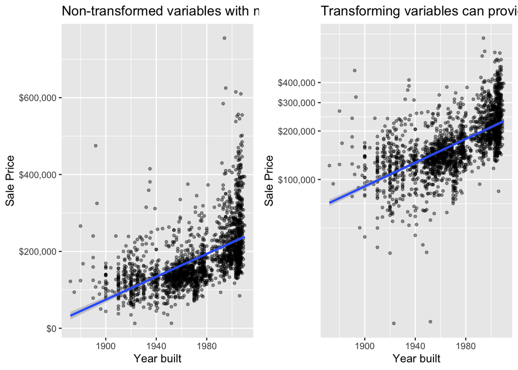

```r
p01 <- ggplot(
    data = ames_train,
    mapping = aes(
        x = Year_Built,
        y = Sale_Price)) +
    geom_point(
        size = 1,
        alpha = 0.4) +
    geom_smooth(
        method = "lm",
        se = TRUE) +
    scale_y_continuous(
        "Sale Price",
        labels = scales::dollar) +
    xlab("Year built") +
    ggtitle("Non-transformed variables with non-linear relationships")

p02 <- ggplot(
    data = ames_train,
    mapping = aes(
        x = Year_Built,
        y = Sale_Price)) +
    geom_point(
        size = 1,
        alpha = 0.4) +
    geom_smooth(
        method = "lm",
        se = TRUE) +
    scale_y_log10(
        "Sale Price",
        labels = scales::dollar,
        breaks = seq(0, 400000, by = 100000)) +
    xlab("Year built") +
    ggtitle("Transforming variables can provide a near-linear relationship")

gridExtra::grid.arrange(
    p01,
    p02,
    nrow = 1)
```

#### Constant variance amongst residuals

A linear regression model assumes residuals have constant variance across observations. The following charts show how the assumption is violated in the simple regression model with only one variable.

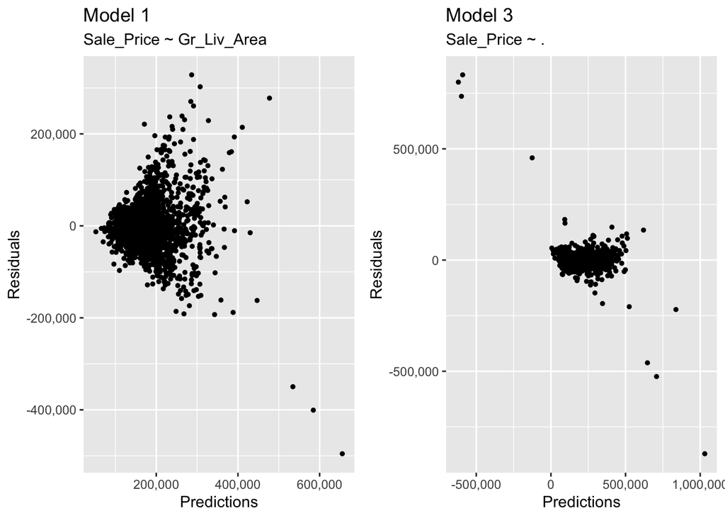

```r
df_01 <- broom::augment(
    cv_model_01$finalModel,
    data = ames_train)

p11 <- ggplot(
    data = df_01,
    mapping = aes(
        x = .fitted,
        y = .resid))

df_02 <- broom::augment(
    cv_model_02)

p12 <- ggplot(
    data = df_02,
    mapping = aes(
        x = .pred,
        y = .resid)) +
    geom_point(
        size = 1,
        alpha = 4) +
    xlab("Predictions") +
    scale_x_continuous(
        labels = scales::label_comma()) +
    ylab("Residuals") +
    scale_y_continuous(
        labels = scales::label_comma()) +
    ggtitle(
        "Model 1",
        subtitle = "Sale_Price ~ Gr_Liv_Area")

df_22 <- broom::augment(
    cv_model_22)

p14 <- ggplot(
    data = df_22,
    mapping = aes(
        x = .pred,
        y = .resid)) +
    geom_point(
        size = 1,
        alpha = 4) +
    xlab("Predictions") +
    scale_x_continuous(
        labels = scales::label_comma()) +
    ylab("Residuals") +
    scale_y_continuous(
        labels = scales::label_comma()) +
    ggtitle(
        "Model 3",
        subtitle = "Sale_Price ~ .")

gridExtra::grid.arrange(
    p12,
    p14,
    nrow = 1)
```

#### No autocorrelation

Linear regression models assume that residuals are independent and uncorrelated. If this is not true, then the standard errors of the coefficients will be biased, leading to narrower prediction intervals that they should.

#### More observations than predictors

The OLS are not obtainable if the number of predictors is larger than the number of observations.

#### Multicollinearity

The presence of collinearity can pose problems in the OLS, since it can be difficult to separate out the individual effects of collinear variables on the response.

### Principal Component Regression

Principal component analysis is a technique to reduce a set of many variables that might be highly correlated down to a smaller number of metrics that are independent, and capture as much variability as possible.

This step can be done with the `tidymodels` `recipes` package. Previous normalization of the variables is advised.

The book shows an example with `caret`, but I’ll show how to do the same with `tidymodels` instead.

```r
pcr_rec_01 <- recipes::recipe(
    Sale_Price ~ .,
    data = ames_train) %>%
    recipes::step_novel(
        recipes::all_factor_predictors()) %>%
    recipes::step_dummy(
        recipes::all_factor_predictors()) %>%
    recipes::step_nzv(
        recipes::all_predictors()) %>%
    recipes::step_normalize(
        recipes::all_numeric_predictors()) %>%
    recipes::step_pca(
        recipes::all_numeric_predictors(),
        num_comp = 5)

pcr_model_01 <- parsnip::linear_reg() %>%
    parsnip::set_engine("lm") %>%
    parsnip::set_mode("regression")

pcr_folds_01 <- rsample::vfold_cv(
    data = ames_train,
    v = 10)

pcr_wf_01 <- workflows::workflow() %>%
    workflows::add_recipe(pcr_rec_01) %>%
    workflows::add_model(
        pcr_model_01)

# Fit resamples and measure performance of the model

pcr_wf_02 <- pcr_wf_01 %>%
    tune::fit_resamples(
        pcr_folds_01,
        control = tune::control_resamples(
            verbose = FALSE))

pcr_wf_02 %>%
    tune::collect_metrics()
```

```
## # A tibble: 2 × 6
##   .metric .estimator      mean     n   std_err .config
##   <chr>   <chr>          <dbl> <int>     <dbl> <chr>
## 1 rmse    standard   41196.       10 1583.     Preprocessor1_Model1
## 2 rsq     standard       0.740    10    0.0170 Preprocessor1_Model1
```

```r
# Final fit with all the training data

pcr_wf_03 <- pcr_wf_01 %>%
    parsnip::fit(
        data = ames_train)

pcr_wf_03 %>%
    tidy()
```

```
## # A tibble: 6 × 5
##   term        estimate std.error statistic   p.value
##   <chr>          <dbl>     <dbl>     <dbl>     <dbl>
## 1 (Intercept)  180923.      916.    198.   0
## 2 PC1          -15773.      229.    -68.9  0
## 3 PC2           -3066.      351.     -8.73 5.06e- 18
## 4 PC3            1724.      390.      4.42 1.02e-  5
## 5 PC4          -11466.      418.    -27.4  3.28e-141
## 6 PC5            3081.      432.      7.14 1.32e- 12
```

### Partial least squares

This is a similar technique to principal component analysis, but in these case the principal components are calculated so as to maximise correlation to the outcome variable.

### Feature interpretation

The interpretation of features in linear regression models is straight-forward. The model assumes a monotonic linear relationship between the predictor variables and the response.

The `vip` package allows to visualize the most important variables in a linear regresion model.

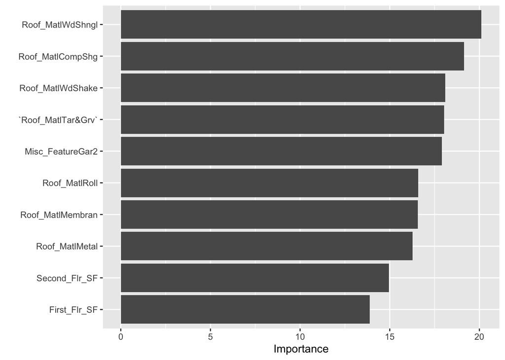

```r
vip::vip(model_wf_03)
```